[figure not shown]

[figure not shown]

# Introduction à l’halieutique

Les outils : R, Quarto et la recherche reproductible

Laurent Dubroca

23/11/2026

## Plan

1. **R** : un langage pour analyser des données
2. **Quarto** : écrire le texte et le code dans un même document
3. **La recherche reproductible** : pourquoi documenter ce que l’on fait
4. **Dans un bureau d’études** : gagner du temps et la confiance des clients
5. **Partager** : les dépôts de données et de code ouverts

**Objectif** : comprendre *pourquoi* on travaille avec des scripts et des documents Quarto, avant d’apprendre *comment* dans le TD.

## R

01.

Un langage pour analyser des données

## Qu’est-ce que R ?

- Un **langage de programmation** et un **environnement** pour les statistiques et les graphiques (Ihaka et Gentleman 1996; R Core Team 2024)
- **Libre et gratuit** (licence GPL), sous Windows, macOS et Linux
- Conçu au début des années 1990 par R. Ihaka et R. Gentleman (Auckland), version 1.0 en 2000, aujourd’hui maintenu par la *R Core Team*
- Extensible par des **packages** : plus de 20 000 sur le dépôt officiel [CRAN](https://cran.r-project.org/)

**On ne clique pas, on écrit**

```r
captures <- c(120, 95, 143)
mean(captures)
```

```
#> [1] 119.3333
```

Chaque étape de l’analyse est écrite, donc **lisible, vérifiable et rejouable**.

## Pourquoi R en halieutique ?

**Le langage commun des halieutes**

- Utilisé par les groupes d’experts du **CIEM** pour les évaluations de stocks
- Données et méthodes publiées dans le cadre **TAF** (ICES, s. d.)
- Statistiques, modèles, cartes, rapports : un seul outil

**Quelques packages du domaine**

| Package | Usage |
| --- | --- |
| `icesDatras`, `icesTAF` | accès aux données et au cadre du CIEM |
| `stockassessment` | modèle d’évaluation SAM |
| `r4ss` | sorties du modèle Stock Synthesis |
| `FLCore` (FLR) | simulation de gestion |
| `vmstools` | données de positionnement des navires |

Seuls `icesDatras` et `icesTAF` s’installent depuis le CRAN ; les autres depuis GitHub ou [r-universe](https://r-universe.dev).

## L’environnement de travail : RStudio

R s’utilise via un **environnement de développement** (IDE) : [RStudio](https://posit.co/download/rstudio-desktop/) (ou [Positron](https://positron.posit.co/)).

| Panneau | Rôle |
| --- | --- |
| **Éditeur** | scripts `.R` et documents `.qmd` |
| **Console** | exécution des commandes |
| **Environnement** | objets en mémoire |
| **Fichiers / Graphiques / Aide** | navigation, figures, documentation |

**Bonnes habitudes dès le départ**

- travailler dans un **projet RStudio** (`.Rproj`)
- utiliser des **chemins relatifs** (`data/captures.csv`) plutôt qu’absolus (`C:/Users/moi/...`)
- ne **pas** sauvegarder l’espace de travail (`.RData`) : c’est le script qui fait foi

## Quarto

02.

Écrire le texte et le code dans un même document

## L’idée : la programmation lettrée

> « Au lieu d’imaginer que notre tâche principale est de dire à un ordinateur quoi faire, concentrons-nous plutôt sur l’explication à des êtres humains de ce que nous voulons que l’ordinateur fasse. »

> D. Knuth, *Literate programming* (Knuth 1984)
- **Texte** (le raisonnement) et **code** (les calculs) dans un **même fichier**
- Les résultats (chiffres, tableaux, figures) sont **calculés au moment de la compilation**

**Fini le copier-coller**

Méthode classique : analyse dans un logiciel → copier les chiffres → coller dans Word → recommencer à chaque modification.

Avec Quarto : on modifie les données ou le code, on **recompile**, et tout le document est à jour.

## Anatomie d’un document `.qmd`

````markdown
---
title: "Débarquements de sole"
author: "Prénom Nom"
format: html
---

## Introduction

Les débarquements sont présentés
par **année**.

```{r}
#| label: fig-sole
#| fig-cap: "Débarquements (t)"
plot(annee, tonnage, type = "b")
```

Le total est de `r sum(tonnage)` t.
````

1. **En-tête YAML** (entre `---`) : titre, auteur, format de sortie
2. **Texte en Markdown** : titres `##`, **gras**, *italique*, listes, liens
3. **Blocs de code R** : exécutés à la compilation ; options `#|` (légende, affichage du code…)
4. **Code en ligne** : un chiffre calculé directement dans une phrase

## Un fichier source, plusieurs sorties

```
flowchart LR
  A["document.qmd<br/>texte + code R"] --> B["knitr<br/>exécute le code R"]
  B --> C["document.md<br/>texte + résultats"]
  C --> D["Pandoc<br/>conversion"]
  D --> E["HTML"]
  D --> F["PDF"]
  D --> G["Word"]
  D --> H["Présentation"]
  D --> I["Site web, livre"]
```

Cette présentation est elle-même un document Quarto, comme les TD du cours.

## La recherche reproductible

03.

Pourquoi documenter ce que l’on fait

## Une crise de la reproductibilité

Enquête auprès de **1 576 chercheurs** (Baker 2016) :

- **plus de 70 %** ont déjà échoué à reproduire les résultats d’un collègue
- **plus de 50 %** ont échoué à reproduire **leurs propres** résultats
- 52 % parlent d’une « crise significative »

**En écologie**

Seuls **27 %** des articles publiés dans 14 revues d’écologie (2015-2019) et reposant sur des analyses partageaient leur code (Culina et al. 2020).

## Reproduire, répliquer : de quoi parle-t-on ?

- **Reproductible** : mêmes données + même code → mêmes résultats
- **Réplicable** : nouvelles données + même méthode → mêmes conclusions ?

En écologie, les observations de terrain sont souvent **impossibles à refaire** (une campagne, une année, un événement climatique). La **reproductibilité computationnelle** reste toujours atteignable (Powers et Hampton 2019).

**Le spectre de la reproductibilité** (Peng 2011)

| Niveau | Ce qui est partagé |
| --- | --- |
| Non reproductible | publication seule |
| ↓ | + code |
| ↓ | + code et données |
| ↓ | + code, données et environnement logiciel complet |
| **Étalon-or** | réplication complète |

## L’Ocean Health Index en une figure

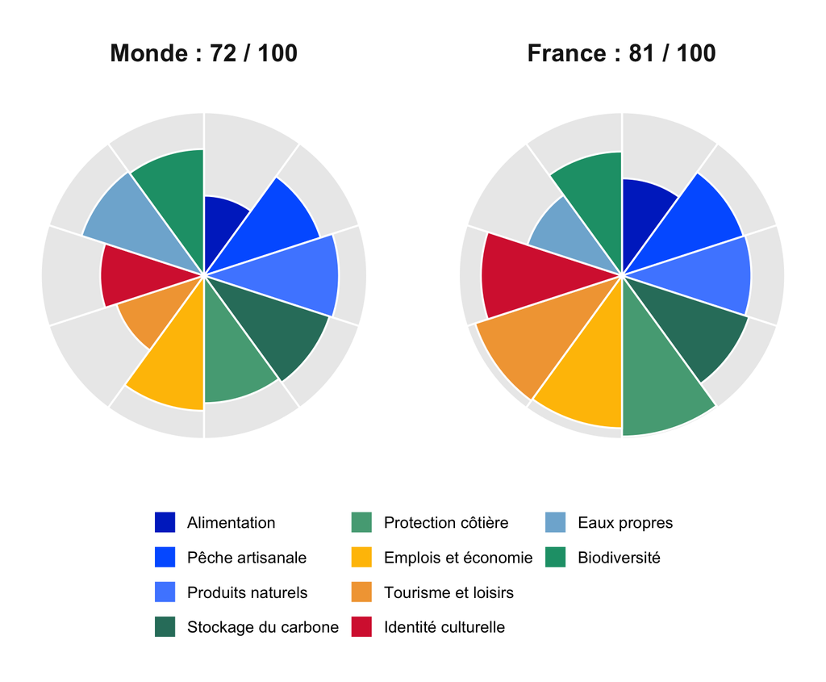

- Un indice de **0 à 100** qui mesure la capacité de l’océan à fournir durablement **10 bénéfices** aux sociétés humaines (Halpern et al. 2012)
- Chaque **pétale** = un objectif ; sa longueur = son score
- **Alimentation** (pêche et aquaculture) : l’un des scores les plus faibles au niveau mondial

Scores 2025 (OHI-Science 2025)

## Exemple marin : l’Ocean Health Index

- L’**Ocean Health Index** évalue chaque année la santé des eaux de 220 pays et territoires (leurs ZEE)
- Avant : tableurs, copier-coller, procédures connues de quelques personnes → difficile de refaire l’évaluation chaque année
- Après : **R, Git/GitHub et documents R Markdown** → l’évaluation est **refaite plus vite, avec moins d’erreurs**, et elle est mieux partagée

« *Our path to better science in less time using open data science tools* »

Lowndes et al. (2017)

## En halieutique : le cadre TAF du CIEM

Chaque évaluation de stock du CIEM peut être publiée comme un **dépôt TAF** (ICES, s. d.) :

```
boot/       données initiales et logiciels
data.R      préparation des données
model.R     ajustement du modèle
output.R    extraction des résultats
report.R    tableaux et figures du rapport
```

**Pourquoi c’est essentiel**

Avis scientifique → **TAC** (totaux admissibles de captures) → quotas → revenus des pêcheurs.

Une décision aux conséquences économiques fortes doit pouvoir être **vérifiée par tous** : scientifiques, gestionnaires, professionnels, ONG.

## Les bonnes pratiques

D’après Sandve et al. (2013) et Wilson et al. (2017) :

- **Ne jamais modifier les données brutes** : on les lit, on les transforme par script
- **Tout faire par script** : pas d’étape manuelle non tracée
- **Organiser le projet** : `data/`, `R/`, `output/`, un fichier `README`
- **Documenter** : commentaires, texte explicatif (Quarto)
- **Versionner** le code (Git)
- **Noter les versions** des logiciels (`sessionInfo()`)
- **Partager** code et données avec la publication

**Votre premier collaborateur, c’est vous dans 6 mois.**

Il ne se souviendra ni de l’ordre des étapes, ni du fichier corrigé à la main, ni du filtre appliqué « juste pour voir ».

## Des données FAIR

Principes **FAIR** (Wilkinson et al. 2016) :

| **F** | *Findable* | trouvable : identifiant pérenne (DOI), métadonnées |
| --- | --- | --- |
| **A** | *Accessible* | accessible : protocole ouvert, conditions d’accès claires |
| **I** | *Interoperable* | interopérable : formats et vocabulaires standards |
| **R** | *Reusable* | réutilisable : licence, provenance, documentation |

FAIR ≠ ouvert : des données confidentielles (données de pêche individuelles, par exemple) peuvent être FAIR avec un accès restreint.

La science ouverte en écologie : Hampton et al. (2015)

## Dans un bureau d’études

04.

Gagner du temps et la confiance des clients

## Le contexte

Un bureau d’études en environnement marin produit :

- des **suivis réglementaires** annuels (qualité de l’eau, benthos, ressources halieutiques)
- des **études d’impact** (parcs éoliens en mer, extractions de granulats, ports)
- des **rapports récurrents** pour des clients publics ou privés

**Toujours les mêmes analyses, sur des données qui changent.**

**Le scénario classique**

Le rapport 2025 a été fait dans un tableur et un traitement de texte, par une personne qui a quitté l’entreprise.

Le client demande le rapport 2026…

## Gagner du temps : le rapport paramétré

````markdown
---
title: "Suivi halieutique"
format: docx
params:
  annee: 2026
  site: "Parc éolien de Courseulles"
---

```{r}
donnees <- read.csv("data/suivi.csv")
donnees <- subset(donnees, annee == params$annee)
```

Bilan de l’nnée `r params$annee` sur le site
`r params$site` : ...
````

```bash
quarto render rapport.qmd -P annee:2027
```

**Une mise à jour = une commande**

- nouvelles données → nouveau rapport complet
- un rapport par site, par espèce, par client avec le **même modèle**
- le temps gagné va à l’**interprétation**, pas à la mise en forme

## Gagner la confiance des clients

**Les erreurs manuelles coûtent cher**

- Un article d’économie très influent sur la dette publique contenait une **erreur de sélection de cellules** dans un tableur (Herndon et al. 2014)
- Environ **20 %** des articles de génomique joignant des listes de gènes sous Excel comportaient des **conversions automatiques erronées** (gènes transformés en dates) (Ziemann et al. 2016)

**La traçabilité comme argument commercial**

- **Auditabilité** : chaque chiffre du rapport remonte au code et aux données
- **Contre-expertise** facilitée : un tiers peut tout relancer
- **Continuité** : le savoir-faire reste dans l’entreprise, pas dans la tête d’une personne
- **Qualité** : cohérent avec les démarches qualité (type ISO 9001)

## Bilan : deux façons de travailler

|  | Tableur + copier-coller | Script R + Quarto |
| --- | --- | --- |
| **Premier rapport** | rapide | plus long (écrire le code) |
| **Rapports suivants** | aussi long que le premier | quelques minutes |
| **Traçabilité** | faible : étapes manuelles | totale : tout est écrit |
| **Erreurs de recopie** | fréquentes | fortement réduites |
| **Transmission** | dépend d’une personne | le code documente la démarche |
| **Contre-expertise** | difficile | relancer le code |

L’investissement initial est vite rentabilisé dès qu’une analyse doit être **refaite**, **mise à jour** ou **vérifiée**.

## Partager

05.

Les dépôts de données et de code ouverts

## Où déposer données, code et rapports ?

| Dépôt | Contenu | Particularités |
| --- | --- | --- |
| [Zenodo](https://zenodo.org) | données, code, rapports, présentations | généraliste (CERN), **DOI** gratuit, lien automatique avec GitHub |
| [SEANOE](https://www.seanoe.org) | données marines | éditeur de données de l’Ifremer, DOI, citable |
| [Archimer](https://archimer.ifremer.fr) | publications, rapports, thèses | archive ouverte de l’Ifremer |
| [Recherche Data Gouv](https://recherche.data.gouv.fr) | données de recherche | entrepôt national français |
| data.gouv.fr | données publiques | plateforme ouverte de l’État |
| [HAL](https://hal.science) | publications | archive ouverte nationale |
| [Software Heritage](https://www.softwareheritage.org) | code source | archive universelle et pérenne du logiciel |
| [GitHub](https://github.com) / [GitLab](https://gitlab.com) | code versionné | travail collaboratif (pas un archivage pérenne) |
| [PANGAEA](https://pangaea.de) | données des sciences de la Terre et de l’environnement | DOI, liés aux revues |
| [Dryad](https://datadryad.org) | données associées aux articles | généraliste, DOI, liés aux revues |

## Où trouver des données marines et halieutiques ?

- [ICES Data Portal](https://data.ices.dk) : campagnes scientifiques (DATRAS), évaluations de stocks
- [EMODnet](https://emodnet.ec.europa.eu) : réseau européen de données marines (biologie, bathymétrie, activités humaines…)
- [OBIS](https://obis.org) / [GBIF](https://www.gbif.org) : occurrences d’espèces
- data.ifremer.fr et [SEXTANT](https://sextant.ifremer.fr) : données et cartes de l’Ifremer
- [FAO FishStat](https://www.fao.org/fishery/en/fishstat) : statistiques mondiales de pêche

**Bien partager, c’est :**

- un format ouvert (CSV plutôt que XLSX)
- des métadonnées (qui, quoi, où, quand, comment)
- une **licence** explicite (CC-BY pour les données, MIT ou GPL pour le code)
- un **DOI** pour être cité

## À retenir

- **R** : un langage libre, standard en halieutique
- **Quarto** : texte + code + résultats dans un seul document, plusieurs formats de sortie
- **Reproductible** = mêmes données + même code → mêmes résultats
- En recherche : **crédibilité**, vérification, réutilisation
- En entreprise : **gain de temps** et **confiance** des clients
- **Partager** sur des dépôts ouverts, avec DOI et licence

**Place au TD**

`applications/02_outils_application.qmd`

1. Travailler avec un document Quarto
2. Les bases de R
3. Explorer des objets
4. Installer et charger des packages
5. Graphiques en R de base et avec ggplot2 (Wickham 2016)

## Références

Allaire, J. J., Charles Teague, Carlos Scheidegger, Yihui Xie, et Christophe Dervieux. 2022. *Quarto*. Released. https://quarto.org.

Baker, Monya. 2016. « 1,500 Scientists Lift the Lid on Reproducibility ». *Nature* 533 (7604): 452‑54. https://doi.org/10.1038/533452a.

Culina, Antica, Ilona van den Berg, Simon Evans, et Alfredo Sánchez-Tójar. 2020. « Low Availability of Code in Ecology: A Call for Urgent Action ». *PLOS Biology* 18 (7): e3000763. https://doi.org/10.1371/journal.pbio.3000763.

Halpern, Benjamin S., Catherine Longo, Darren Hardy, et al. 2012. « An Index to Assess the Health and Benefits of the Global Ocean ». *Nature* 488 (7413): 615‑20. https://doi.org/10.1038/nature11397.

Hampton, Stephanie E., Sean S. Anderson, Sarah C. Bagby, et al. 2015. « The Tao of Open Science for Ecology ». *Ecosphere (Washington, D.C)* 6 (7): art120. https://doi.org/10.1890/ES14-00402.1.

Herndon, Thomas, Michael Ash, et Robert Pollin. 2014. « Does High Public Debt Consistently Stifle Economic Growth? A Critique of Reinhart and Rogoff ». *Cambridge Journal of Economics* 38 (2): 257‑79. https://doi.org/10.1093/cje/bet075.

ICES. s. d. *Transparent Assessment Framework (TAF)*. International Council for the Exploration of the Sea, Copenhague. https://taf.ices.dk.

Ihaka, Ross, et Robert Gentleman. 1996. « R: A Language for Data Analysis and Graphics ». *Journal of Computational and Graphical Statistics* 5 (3): 299‑314. https://doi.org/10.1080/10618600.1996.10474713.

Knuth, Donald E. 1984. « Literate Programming ». *The Computer Journal* 27 (2): 97‑111. https://doi.org/10.1093/comjnl/27.2.97.

Lowndes, Julia S. Stewart, Benjamin D. Best, Courtney Scarborough, et al. 2017. « Our Path to Better Science in Less Time Using Open Data Science Tools ». *Nature Ecology & Evolution* 1: 0160. https://doi.org/10.1038/s41559-017-0160.

OHI-Science. 2025. *Ocean Health Index – Évaluation Mondiale 2025 (Fichier OHI_final_formatted_scores_2025-12-03.Csv)*. Dépôt GitHub OHI-Science/ohi-global, yearly_results/global2025. https://github.com/OHI-Science/ohi-global.

Peng, Roger D. 2011. « Reproducible Research in Computational Science ». *Science* 334 (6060): 1226‑27. https://doi.org/10.1126/science.1213847.

Powers, Stephen M., et Stephanie E. Hampton. 2019. « Open Science, Reproducibility, and Transparency in Ecology ». *Ecological Applications* 29 (1): e01822. https://doi.org/10.1002/eap.1822.

R Core Team. 2024. *R: A Language and Environment for Statistical Computing*. Manual. R Foundation for Statistical Computing. https://www.R-project.org/.

Sandve, Geir Kjetil, Anton Nekrutenko, James Taylor, et Eivind Hovig. 2013. « Ten Simple Rules for Reproducible Computational Research ». *PLOS Computational Biology* 9 (10): e1003285. https://doi.org/10.1371/journal.pcbi.1003285.

UK Government Analysis Function. 2022. *Reproducible Analytical Pipelines (RAP) Strategy*. Government Analysis Function, Royaume-Uni. https://analysisfunction.civilservice.gov.uk/policy-store/reproducible-analytical-pipelines-strategy/.

Wickham, Hadley. 2016. *Ggplot2: Elegant Graphics for Data Analysis*. Springer-Verlag New York. https://ggplot2.tidyverse.org.

Wilkinson, Mark D. et al. 2016. « The FAIR Guiding Principles for Scientific Data Management and Stewardship ». *Scientific Data* 3: 160018. https://doi.org/10.1038/sdata.2016.18.

Wilson, Greg, Jennifer Bryan, Karen Cranston, Justin Kitzes, Lex Nederbragt, et Tracy K. Teal. 2017. « Good Enough Practices in Scientific Computing ». *PLOS Computational Biology* 13 (6): e1005510. https://doi.org/10.1371/journal.pcbi.1005510.

Xie, Yihui, J. J. Allaire, et Garrett Grolemund. 2018. *R Markdown: The Definitive Guide*. Chapman and Hall/CRC. https://bookdown.org/yihui/rmarkdown.

Ziemann, Mark, Yotam Eren, et Assam El-Osta. 2016. « Gene Name Errors Are Widespread in the Scientific Literature ». *Genome Biology* 17: 177. https://doi.org/10.1186/s13059-016-1044-7.